# Reproducible Research: Peer Assessment 1

## Loading and preprocessing the data

The source data format already suits most of the analysis that will be performed. No initial manipulation is required.

```r
data <- read.csv('activity.csv', stringsAsFactors = FALSE)
```

## What is mean total number of steps taken per day?

### Total steps per day

To graph the total number of steps per day, the data must be aggregated:

- aggregate by date.
- sum the number of steps taken for each day.

Following aggregation, the data can be graphed in a histogram.

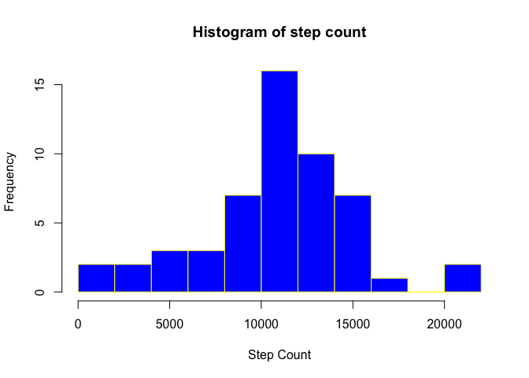

```r
steps_per_day <- aggregate(data$steps, by = list(data$date), FUN='sum')
names(steps_per_day) <- c('date', 'steps')

steps_per_day <- steps_per_day[!is.na(steps_per_day$steps),]

hist(x = steps_per_day$steps,
     breaks = 10,
     ylab = 'Frequency',
     xlab = 'Step Count',
     main = 'Histogram of step count',
     col = 'blue',
     border = 'yellow')
```

### Mean and median steps per day

The previously aggregated data can be used for mean/median calculations.

```r
original_mean <- mean(steps_per_day$steps, na.rm = TRUE)
original_median <- median(steps_per_day$steps, na.rm = TRUE)

original_mean
```

```
## [1] 10766.19
```

```r
original_median
```

```
## [1] 10765
```

## What is the average daily activity pattern?

### Average steps across 5 minute intervals

The data can then be plotted in a time series graph.

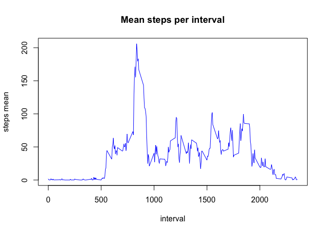

```r
steps_per_interval <- aggregate(data$steps, by = list(data$interval), FUN='mean', na.rm = TRUE)
names(steps_per_interval) <- c('interval','stepsmean')

plot(x = steps_per_interval$interval,
     y =  steps_per_interval$stepsmean,
     xlab = 'interval',
     ylab = 'steps mean',
     main = 'Mean steps per interval',
     type = 'l',
     col = 'blue')
```

### Interval with maximum average steps

The data aggregated in the previous step can be used to find which interval has the highest average number of steps across all days.

```r
steps_per_interval[steps_per_interval$stepsmean == max(steps_per_interval$stepsmean), 'interval']
```

```
## [1] 835
```